# Assignment 3: Exploratory analysis and PCA

## Exercise 2: the M-A plot & volcano

Next let’s look at your DEA results from the previous assignment. You should have a csv file with the summary statistics named something like the following code block. Change the code as appropriate for your own data path:

```r
dea <- read.csv(file = file.path(course_directory, "data", "treatment_TEAD2_vs_CRISPRi_CONTROL.csv"))
knitr::kable(head(dea[order(dea$padj),], n=20))
```

|  | Symbol | baseMean | log2FoldChange | lfcSE | stat | pvalue | padj |
| --- | --- | --- | --- | --- | --- | --- | --- |
| 5735 | MAP1S | 16924.8096 | -2.105323 | 0.1270187 | -16.57490 | 0 | 0 |
| 1180 | TEAD2 | 902.4992 | -2.549910 | 0.1599461 | -15.94230 | 0 | 0 |
| 26228 | AC008761.1 | 2331.0339 | -2.286792 | 0.1478909 | -15.46269 | 0 | 0 |
| 4946 | LRP1 | 4090.9965 | -1.541289 | 0.1031763 | -14.93840 | 0 | 0 |
| 5755 | HELZ2 | 8822.3633 | -1.683875 | 0.1147913 | -14.66902 | 0 | 0 |
| 456 | GRN | 19939.0931 | -1.304058 | 0.0955542 | -13.64731 | 0 | 0 |
| 23359 | AP006621.1 | 6564.7926 | -1.504271 | 0.1112375 | -13.52306 | 0 | 0 |
| 13588 | AC138932.1 | 5828.0286 | -1.688903 | 0.1264488 | -13.35642 | 0 | 0 |
| 1380 | CIC | 15568.9163 | -1.485361 | 0.1115023 | -13.32134 | 0 | 0 |
| 7561 | PTPRF | 3566.0371 | -1.382972 | 0.1037431 | -13.33074 | 0 | 0 |
| 25204 | CORO7 | 8878.5782 | -1.399431 | 0.1050958 | -13.31576 | 0 | 0 |
| 14674 | HMGB1 | 8035.0923 | 1.166593 | 0.0904246 | 12.90128 | 0 | 0 |
| 22591 | AC068580.4 | 24451.0588 | -1.304989 | 0.1018234 | -12.81620 | 0 | 0 |
| 5654 | TMEM8A | 17929.0493 | -1.447018 | 0.1135946 | -12.73844 | 0 | 0 |
| 11503 | CDK1 | 3203.3531 | 1.376904 | 0.1085381 | 12.68590 | 0 | 0 |
| 4861 | CBX3 | 6066.4541 | 1.171721 | 0.0929336 | 12.60816 | 0 | 0 |
| 3215 | UNC5B | 1888.0683 | -1.521238 | 0.1207241 | -12.60095 | 0 | 0 |
| 7520 | RERE | 9687.3249 | -1.229683 | 0.0979778 | -12.55063 | 0 | 0 |
| 1114 | SREBF1 | 18948.9664 | -1.253214 | 0.0999053 | -12.54401 | 0 | 0 |
| 2153 | CSF2RB | 683.7631 | -2.170296 | 0.1735831 | -12.50292 | 0 | 0 |

1. Using whatever method you’re most comfortable with (base graphics or ggplot), generate an M-A plot using your dea set from GENAVi:

```r
### plot(y = dea$log2FoldChange...  etc etc)
```

[output not shown]

2. Generate a volcano plot from the same data frame.

```r
### plot(x = dea$log2FoldChange... etc etc)
```

[output not shown]

## Exercise 3: Principle Components Analysis

Our goal is to give you some conceptual basis to understand what is happening in a Principle components analysis to help guide you in interpretation. In addition to this week’s lecture and the [reading material](https://www.nature.com/articles/nbt0308-303) you may find this video helpful.

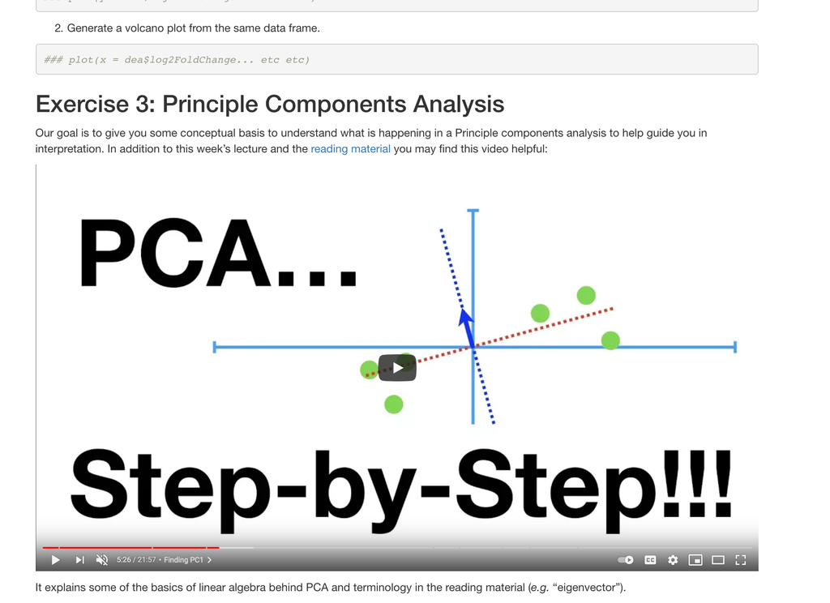

It explains some of the basics of linear algebra behind PCA and terminology in the reading material (*e.g.* “eigenvector”).

Here is [another resource online](https://stats.stackexchange.com/questions/2691/making-sense-of-principal-component-analysis-eigenvectors-eigenvalues) with excellent, intuitive visualizations and explanations.

Open a new GENAVi window and load your data and metadata files via the Gene Expression and Differential Expression Analysis tabs as you did in the previous labs. **Note you may need to run this command from a separate instance of R or the shinyapps.io webserver so that you can continue to interact with this notebook**:

```r
shiny::runGitHub("alpreyes/GENAVi")
```

To run PCA or any of the functions from the Visualization tab you need to select some genes. Under the Gene selection menu you *could* select Select 1000 genes of highest variance but we will ignore that for now.

1. Create a gene list of your differentially expressed genes from Lab 2. There are many ways to do this; here is an example for the `dea` object we created in the exercise above:

```r
sig_genes <- with(dea, log2FoldChange - lfcSE > 0.5)
write.table(
  dea[sig_genes, ]$Symbol,
  file = file.path(course_directory, "data", "tead_sig_genes.csv"),
  row.names = FALSE,
  col.names = FALSE,
  quote = FALSE)
```

On the Gene Expression tab upload your genelist via the Gene selection menu. Now click on the Visualization tab. It may take a minute to render. Once the heatmap is generated, click on the PCA plots button. Choose Selected genes from the PCA Genes menus. Download a copy of the image and link it below in place of the smiley face.

[figure not shown]

Now go back to the gene expression tab and select Deselect all genes from the Gene selection menu. Then search for your target gene (or any gene of interest). Select some number of genes (at least 3). Return to the Visualization tab and make sure PCA genes >> Selected genes is selected. Link your image here:

[figure not shown]

### Questions for exercise 3

1. Describe the major differences you see in the two plots above.

2. Why are the axes different?

3. What is the largest number of principle components you can have?

4. Why does GENAVi provide the capability of generating an HTML report?

Instructions: change the color of the *best* answer choice below to red. Some answer choices are true but not best.

**a. To make you look like a legit hacker.**

**b. For transparency and reproducibility.**

**c. For troubleshooting your analysis.**

**d. To help you learn to write code.**

## Exercise 4: t-SNE

Watch this

[figure not shown]

.

Question for exercise 4.

1. Is t-SNE necessary for a single CRISPRi experiment with 4 samples and a single contrast of interest? Why or why not?

2. Is there a relationship between PCA analysis and t-SNE? What problem does PCA present that methods like t-SNE and a related procedure called UMAP potentially solve?

## Exercise 5 (for Kate’s lecture)

You are a bioinformatician! Your trusted bench scientist colleague brings you a dataset consisting of two replicates each across 3 treatments, including 2 control conditions, one of which has marginal added value (3 x 2 = 6 samples). The replicates are independent library preparations of the same samples. Your colleague says (enthusiastically) to you “I can add more replicates, you know, to get better statistics!” What would you say to them to rescue this experiment? First list the possible types of replication and what types of experimental error they measure and rank their importance. Then, assuming you have budget for library prep and sequencing of up to 4 more samples, make your recommendation.